# Parcial 2

Joshua Cervantes

03 July 2022

# Ejercicio 1

Conforme y muestre el código de una función que determine el valor presente actuarial para un seguro vitalicio, temporal, dotal y dotal puro, en donde el pago del beneficio de “salida/fallo” por un determinado decremento se realiza al final del año de ocurrencia y el beneficio de sobrevivencia al momento de transcurrido el período temporal y habiendo sobrevivido a todos los decrementos. Se debe crear un única función que reciba los parámetros que se indican en el siguiente seudocódigo:

*fseg<-function(TablaMD,decremento,tipo_de_seguro,edad,tasa_interes,enfoque,m)*

Con base en la función anterior calcule, muestre y conforme una tabla con los 32 valores que resultan de combinar los 4 decrementos (tipos de muerte), los 4 tipos de seguro y los dos enfoques. Para esto utilice la tabla de “TablaMD.xlsx” cargada en el Virtual para el laboratorio 7, una tasa de interpete de 4.3% y una edad de 27 años. Lo enfoques son el determinístico (sin usar funciones del paquete respectivo) y estocástico con al menos 5.000 simulaciones.

**Nota** Antes de empezar los tipos de de decrementos son 1,2, 3 y 4 que corresponden a muertes por diabetes, muertes por cancer, muertes cardíacas y muertes otras.

```r
# Se programan dos funciones distintas de acuerdo al tipo de enfoque y se unan en una sola función
# Lo seguros que recibirá la función serán vitalicio, temporarl, dotal y dotal_puro
Axn <- function(TablaMD, decremento, tipo_seguro, edad, tasa_interes, N = 0, w) {
    v <- 1 / (1 + tasa_interes)
    if (tipo_seguro != "dotal_puro") {
        n <- (tipo_seguro == "vitalicio") * (w - edad) +
            (tipo_seguro == "temporal" | tipo_seguro == "dotal") * N
        n <- 0:(n - 1)
        px <- pxt(TablaMD, x = edad, t = n)
        qx <- qxt(TablaMD, x = edad + n, t = 1, decrement = decremento)
        suma <- sum(v^(n + 1) * px * qx)
        if (tipo_seguro == "dotal") {
            dotal <- v^N * pxt(TablaMD, x = edad, t = N)
            suma <- dotal + suma
        }
    } else {
        suma <- v^N * pxt(TablaMD, x = edad, t = N)
    }
    return(suma)
}
```

```r
# Enfoque estocastico
# Primero se construye una funcion que pase el numero de decremento
# al tipo de muerte
tipo_decremento <- function(decremento) {
    decremento <- switch(decremento,
        "MuertesDiab",
        "MuertesCanc",
        "MuerteCard",
        "MuertesOtras",
    )
    return(decremento)
}

Axn_s <- function(TablaMD, decremento, tipo_seguro, edad, tasa_interes, N = 0, simulaciones, w) {
    simulaciones <- simulaciones
    v <- 1 / (1 + tasa_interes)
    if (tipo_seguro != "dotal_puro") {
        n <- (tipo_seguro == "vitalicio") * (w - edad) +
            (tipo_seguro == "temporal" | tipo_seguro == "dotal") * N
        tabla_simulacion <- rmdt(
            n = simulaciones, TablaMD, x = edad, t = n, t0 = "alive",
            include.t0 = FALSE
        )
        fn2 <- function(n) {
            suma <- sum(tipo_decremento(decremento) == tabla_simulacion[, n])
            if (suma > 0) {
                suma <- v^match(tipo_decremento(decremento), tabla_simulacion[, n])
            }
            return(suma)
        }
        n <- 1:simulaciones
        suma <- sum(future_sapply(FUN = fn2, X = n))
        if (tipo_seguro == "dotal") {
            dotal <- v^N * sum(tabla_simulacion[N, ] == "alive")
            suma <- (dotal + suma)
        }
    } else {
        tabla_simulacion <- rmdt(
            n = simulaciones, TablaMD, x = edad, t = N, t0 = "alive",
            include.t0 = FALSE
        )
        suma <- v^N * sum(tabla_simulacion[N, ] == "alive")
        print(suma)
    }
    return(suma / simulaciones)
}
```

```r
# Funcion final
# Enfoques deben ingresarse como estocastico o deterministico
# por defecto tiene deterministico
# Hay que ingresar la temporalidad para el dotal y para el determinístico
# Hay que especificar el tipo de decremento
# Hay que ingresar una tabla de múltiples decrementos
fseg <- function(TablaMD, decremento, tipo_de_seguro, edad, tasa_interes, enfoque = "deterministico", N = 0) {
    if (N == 0 & tipo_de_seguro != "vitalicio") {
        print("Ingresar un valor para N")
    } else {
        w <- getOmega(TablaMD)
        if (enfoque == "deterministico") {
            suma <- Axn(TablaMD, decremento, tipo_de_seguro, edad, tasa_interes, N = N, w)
        } else if (enfoque == "estocastico") {
            suma <- Axn_s(TablaMD, decremento,
                tipo_de_seguro, edad, tasa_interes,
                N = N,
                5000, w
            )
        }
        return(suma)
    }
}
```

```r
# Creacio de la tabla
edad <- 27
tipo_seguro <- c("vitalicio", "temporal", "dotal", "dotal_puro")
tasa_interes <- 0.043
N <- 20
decremento <- as.numeric(1:4)
enfoque <- c("deterministico", "estocastico")
tabla <- data.frame(
    "Decremento" = numeric(), "Vitalicio" = numeric(), "Temporal" = numeric(), "Dotal" = numeric(),
    "Dotal_Puro" = numeric()
)
for (j in enfoque) {
    for (k in decremento) {
        vitalicio <- fseg(TablaMD = tabla_md_1, decremento = k, tipo_de_seguro = "vitalicio", edad = 27, tasa_interes = tasa_interes, enfoque = j, N = 20)
        temporal <- fseg(TablaMD = tabla_md_1, decremento = k, tipo_de_seguro = "temporal", edad = edad, tasa_interes = tasa_interes, enfoque = j, N = 20)
        dotal <- fseg(TablaMD = tabla_md_1, decremento = k, tipo_de_seguro = "dotal", edad = edad, tasa_interes = tasa_interes, enfoque = j, N = 20)
        dotal_puro <- fseg(TablaMD = tabla_md_1, decremento = k, tipo_de_seguro = "dotal_puro", edad = edad, tasa_interes = tasa_interes, enfoque = j, N = 20)
        aux <- data.frame(
            "Decremento" = k, "Vitalicio" = vitalicio, "Temporal" = temporal, "Dotal" = dotal,
            "Dotal_Puro" = dotal_puro
        )
        tabla <- rbind(tabla, aux)
    }
}
```

```
## [1] 1884,5
## [1] 1881
## [1] 1888,8
## [1] 1887,1
```

```r
enfoque <- c(rep("Determinístico", 4), rep("Estocástico", 4))
tabla <- cbind("Enfoque" = enfoque, tabla)
nombres <- c("Enfoque", "Decremento", "Vitalicio", "Temporal", "Dotal", "Dotal puro")
kable(tabla,
    caption = "Seguros", format.args = list(decimal.mark = ",", big.mark = "."),
    col.names = nombres
) %>%
    kable_styling(full_width = F) %>%
    kable_material() %>%
    row_spec(0, bold = T, color = "white", background = "#159957") %>%
    scroll_box(height = "500px", width = "100%")
```

Seguros

| Enfoque | Decremento | Vitalicio | Temporal | Dotal | Dotal puro |
| --- | --- | --- | --- | --- | --- |
| Determinístico | 1 | 0,00470 | 0,00102 | 0,37915 | 0,37814 |
| Determinístico | 2 | 0,05540 | 0,01397 | 0,39210 | 0,37814 |
| Determinístico | 3 | 0,07473 | 0,01200 | 0,39014 | 0,37814 |
| Determinístico | 4 | 0,12948 | 0,04490 | 0,42304 | 0,37814 |
| Estocástico | 1 | 0,00488 | 0,00150 | 0,37541 | 0,37690 |
| Estocástico | 2 | 0,05056 | 0,01329 | 0,39407 | 0,37621 |
| Estocástico | 3 | 0,07440 | 0,01274 | 0,39007 | 0,37776 |
| Estocástico | 4 | 0,12780 | 0,04352 | 0,42413 | 0,37741 |

**Análisis**

Se puede observar que los resultados obtenidos mediante el modelo determinístico y el modelo estocástico son similares, salvo por una diferencia relativa. El seguro dotal es la suma entre el seguro temporal y dotal puro, y de esto se puede destacar que el seguro que mayor valor agrega al seguro dotal es el dotal puro. Otro aspecto importante es que en los seguros vitalicios y temporales, los que tienen mayor valor son los asociados al decremento 4 que corresponde a muerte por otras causas, por lo que se espera que la muerte por esta causa sea la mayor. El que menor valor tiene es el seguro asociado al decremento 1 que corresponde a muerte por diabetes, de forma análoga a lo anterior se espera que esta sea la menor causa de muerte.

# Ejercicio 2

Una persona de 25 años de edad posee un plan de pensión que consiste en una anualidad vitalicia pagada al inicio de cada año a partir de la edad 65. Durante el periodo diferido de 40 años se paga un beneficio de fallecimiento (decremento $J=1$) o por retiro (decremento $J=2$) pagado al final del año de ocurrido el suceso y que consiste en el valor acumulado de la primas pagadas a ese momento utlizando la misma tasa de interés que para el cálculo de la prima. Las primas se pagan al inicio de cada año mientras la persona se mantenga activa en el estado/modelo y hasta edad 64 (inclusive). Para este ejercicio se asume que no existe la contingencia de retiro una vez se inicie con el pago de la anualidad vitalicia, así mismo, considere una tasa de interés de 4.8% y como insumo para la tabla de múltiples decrementos utilice el archivo suministrado.

1. Determine las expresiones algebraicas para calcular la prima de con base en el principio de equivalencia, la pérdida y la reserva a un determinado tiempo.
   $$L =
   \begin{cases}
   \pi v^{K+1}\ddot{s}_{\overline{K+1|}}-\pi
   \ddot{a}_{\overline{K+1|}} \qquad K<40, J=1,2\\
   v^{40}\ddot{a}_{\overline{(K+1)-40|}}-\pi
   \ddot{a}_{\overline{40|}}\qquad K\geq 40, J=1
   \end{cases}$$

Si se aplica el principio de equivalencia se obtiene

$$\mathbb{E}[L]=\sum_{K=40}^{\infty}\left(v^{40}\ddot{a}_{\overline{(K+1)-40|}}-\pi
\ddot{a}_{\overline{40|}}\right)\,_{K}p_{25}^{(\tau)}q_{25+K}^{(1)}$$

Que se cumple si

$$v^{40}\ddot{a}_{65}\,
_{40}p_{25}^{(\tau)}-\pi\ddot{a}_{\overline{40|}}\, _{40}p_{25}$$

Entonces
$$\pi =\frac{v^{40}\ddot{a}_{65}}{\ddot{a}_{\overline{40|}}}$$
Esto hay que multiplicarlo por el beneficio.

2. Calcule la prima de riesgo para el ejercicio si se asume que la anualidad vitalicia paga 80.000 al inicio de cada año si se aplica.

```r
# El beneficio
benefit <- 80000
interest <- 0.048
v <- 1 / (1 + interest)

# Analidad de pension
a_65_md <- v^(40) * sum(v^(0:10) * pxt(tabla_md, x = 65, 0:10))

# Anualidad primas
a_40 <- (1 - v^(40)) / (1 - v)
# Prima por riesgo
(risk_p <- benefit * a_65_md / a_40)
```

```
## [1] 3233,9
```

3. Estime el valor de la pérdida si la persona falleciera en cada hacia al futuro, grafique e interprete.

```r
L <- benefit * v^40 * (1 - v^(1:10)) / (1 - v) - risk_p * (1 - v^(40)) / (1 - v)
(L <- c(rep(0, 40), L))
```

```
##  [1]      0,0      0,0      0,0      0,0      0,0      0,0      0,0      0,0
##  [9]      0,0      0,0      0,0      0,0      0,0      0,0      0,0      0,0
## [17]      0,0      0,0      0,0      0,0      0,0      0,0      0,0      0,0
## [25]      0,0      0,0      0,0      0,0      0,0      0,0      0,0      0,0
## [33]      0,0      0,0      0,0      0,0      0,0      0,0      0,0      0,0
## [41] -47518,2 -35815,7 -24649,2 -13994,2  -3827,2   5874,2  15131,2  23964,2
## [49]  32392,7  40435,1
```

**Figura 1: Vector de pérdidas**

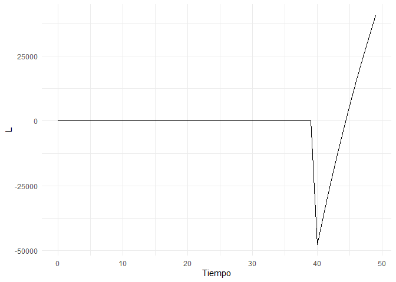

```r
# Graficamos
L <- data.frame(Tiempo = 0:49, L = L)
L %>% ggplot(aes(x = Tiempo, y = L)) +
    geom_line() +
    theme_minimal() +
    scale_color_jcolors(palette = "pal2")
```

4. Conforme la tabla de flujos para el ejercicio asumiendo que $l_{25}$ individuos toman el indiviuos toman el mismo plan de pensiones.

Antes de empezar cabe destacar como es posible determinar la reserva teórica si $t\leq 40$ y entero entonces se tiene
$$\sum_{K=0}^{40-t}(\pi v^{40}\ddot{a}_{\overline{t+K|}}-\pi
\ddot{a}_{\overline{K|}})\,_{K}p_{25+t}^{(\tau)}q_{25+t+K}^{(\tau)}
+\sum_{K=40-t}^{\infty}(v^{35-t}\ddot{a}_{\overline{K-(35-t)|}}-\pi\ddot{a}_{\overline{35-t|}})\,_{K}p_{25+t}^{(\tau)}q_{25+t+K}^{(1)}$$
$$=\pi v^{t}\ddot{a}_{\overline{t|}}(1-\,_{35-t}p^{(\tau)}_{25+t})+
\,_{40-t|}\ddot{a}_{25+t}
-\pi \ddot{a}_{40-t}\,_{40-t}p_{25+t}^{(\tau)}$$
$$=\pi \ddot{s}_{t}$$
En el caso de $t>40$ entonces se cumple que la reserva teórica es
$$\ddot{a}_{65+t}$$
Esto hay que multiplicarlo por el beneficio.

```r
# Personas que permanecen
filas <- 26:nrow(datos)
lx <- datos$lx[filas]

# Decrementos caso 1
d_1 <- datos$Fallecimiento[filas]

# Decrementos caso 2
d_2 <- datos$Retiro[filas]



# Primas inicio
# Fondos inicio
zeros <- rep(0, length(lx) - 1)
primas <- c(risk_p * lx[1:40], rep(0, 10))

# Intereses
intereses <- c(primas[1] * interest, zeros)

# Reclamos decrementos
reclamos <- 1:40
sn <- risk_p * ((1 + interest)^(reclamos) - 1) / (1 - v)
claim_1 <- c(d_1[1:40] * sn, rep(0, 10))
claim_2 <- c(d_2[1:40] * sn, rep(0, 10))

# Monto pension
pension <- c(rep(0, 40), benefit * lx[41:50])

# Fondos fin
fondos_fin <- c(primas[1] + intereses[1] - claim_1[1] - claim_2[1], zeros)

# Sobrevivientes fin
lx_fin <- c(lx[-1], 0)

# Reserva
reserve <- c(fondos_fin[1] / lx_fin[1], zeros)


# Monto inicio
monto_inicio <- c(primas[1], zeros)


# Flujos
flujos <- data.frame(
    "Edad" = 25:74, "Sobrevivientes inicio" = lx, "Prima" = primas, "Monto inicio" = monto_inicio,
    "Intereses" = intereses, "Reclamos fallecimiento" = claim_1,
    "Reclamos retiro" = claim_2, "Monto pension" = pension,
    "Fondos esperados fin" = fondos_fin, "Sobrevivientes final" = lx_fin,
    "Reserva observada" = reserve
)
for (i in 2:nrow(flujos)) {
    monto_inicio[i] <- (flujos$Prima[i] + flujos$Fondos.esperados.fin[i - 1] - flujos$Monto.pension[i])
    flujos$Intereses[i] <- interest * monto_inicio[i]
    flujos$Monto.inicio[i] <- monto_inicio[i]
    flujos$Fondos.esperados.fin[i] <- monto_inicio[i] + flujos$Intereses[i] - flujos$Reclamos.retiro[i] - flujos$Reclamos.fallecimiento[i]
    flujos$Reserva.observada[i] <- flujos$Fondos.esperados.fin[i] / flujos$Sobrevivientes.final[i]
    if (i == nrow(flujos)) {
        flujos$Reserva.observada[i] <- 0
    }
}


# Reserva teorica

reserve <- function(x, t) {
    if (t <= 40) {
        return(risk_p * ((1 + interest)^t - 1) / (1 - v))
    } else {
        k <- 0:10
        pension <- benefit * (sum(v^k * pxt(tabla_md, x = x + t, t = k)))
        return(pension)
    }
}
t <- 1:50
x <- 25
reserva_teorica <- unlist(lapply(FUN = reserve, X = t, x = x))

flujos$Reserva.teorica <- reserva_teorica
flujos <- round(flujos, digits = 2)
nombres <- c(
    "Edad", "Sobrevivientes inicio", "Prima",
    "Monto incio",
    "Intereses", "Reclamos fallecimiento",
    "Reclamos retiro", "Monto pension",
    "Fondos esperados fin", "Sobrevivientes final",
    "Reserva observada", "Reserva teórica"
)
kable(flujos,
    caption = "Flujos", format.args = list(decimal.mark = ",", big.mark = "."),
    col.names = nombres
) %>%
    kable_styling(full_width = F) %>%
    kable_material() %>%
    row_spec(0, bold = T, color = "white", background = "#159957") %>%
    scroll_box(height = "500px", width = "100%")
```

Flujos

| Edad | Sobrevivientes inicio | Prima | Monto incio | Intereses | Reclamos fallecimiento | Reclamos retiro | Monto pension | Fondos esperados fin | Sobrevivientes final | Reserva observada | Reserva teórica |
| --- | --- | --- | --- | --- | --- | --- | --- | --- | --- | --- | --- |
| 25 | 896.795 | 2.900.132.034 | 2.900.132.034 | 139.206.338 | 5.897.054 | 579.538 | 0 | 3.032.861.780 | 894.884 | 3.389,1 | 3.389,1 |
| 26 | 894.884 | 2.893.952.080 | 5.926.813.860 | 284.487.065 | 12.722.671 | 1.082.781 | 0 | 6.197.495.474 | 892.895 | 6.940,9 | 6.940,9 |
| 27 | 892.895 | 2.887.519.882 | 9.085.015.356 | 436.080.737 | 20.579.929 | 1.503.508 | 0 | 9.499.012.657 | 890.824 | 10.663,2 | 10.663,2 |
| 28 | 890.824 | 2.880.822.506 | 12.379.835.163 | 594.232.088 | 29.477.778 | 1.805.951 | 0 | 12.942.783.522 | 888.676 | 14.564,1 | 14.564,1 |
| 29 | 888.676 | 2.873.876.121 | 15.816.659.643 | 759.199.663 | 41.725.215 | 3.525.286 | 0 | 16.530.608.804 | 886.250 | 18.652,3 | 18.652,3 |
| 30 | 886.250 | 2.866.030.716 | 19.396.639.519 | 931.038.697 | 56.149.119 | 5.780.056 | 0 | 20.265.749.042 | 883.550 | 22.936,7 | 22.936,7 |
| 31 | 883.550 | 2.857.299.226 | 23.123.048.267 | 1.109.906.317 | 72.955.304 | 8.639.444 | 0 | 24.151.359.836 | 880.575 | 27.426,8 | 27.426,8 |
| 32 | 880.575 | 2.847.678.417 | 26.999.038.253 | 1.295.953.836 | 92.187.869 | 12.146.049 | 0 | 28.190.658.172 | 877.328 | 32.132,4 | 32.132,4 |
| 33 | 877.328 | 2.837.177.992 | 31.027.836.164 | 1.489.336.136 | 113.341.319 | 20.162.746 | 0 | 32.383.668.234 | 873.726 | 37.063,9 | 37.063,9 |
| 34 | 873.726 | 2.825.529.538 | 35.209.197.772 | 1.690.041.493 | 137.085.231 | 30.026.987 | 0 | 36.732.127.047 | 869.769 | 42.232,1 | 42.232,1 |
| 35 | 869.769 | 2.812.733.054 | 39.544.860.102 | 1.898.153.285 | 163.719.555 | 41.787.558 | 0 | 41.237.506.273 | 865.456 | 47.648,3 | 47.648,3 |
| 36 | 865.456 | 2.798.785.308 | 44.036.291.581 | 2.113.741.996 | 192.981.470 | 55.510.835 | 0 | 45.901.541.271 | 860.796 | 53.324,5 | 53.324,5 |
| 37 | 860.796 | 2.783.715.403 | 48.685.256.674 | 2.336.892.320 | 245.568.942 | 60.814.322 | 0 | 50.715.765.730 | 855.627 | 59.273,2 | 59.273,2 |
| 38 | 855.627 | 2.766.999.451 | 53.482.765.181 | 2.567.172.729 | 305.788.749 | 66.031.504 | 0 | 55.678.117.657 | 849.951 | 65.507,4 | 65.507,4 |
| 39 | 849.951 | 2.748.643.918 | 58.426.761.575 | 2.804.484.556 | 374.108.462 | 71.536.627 | 0 | 60.785.601.042 | 843.765 | 72.040,9 | 72.040,9 |
| 40 | 843.765 | 2.728.639.105 | 63.514.240.147 | 3.048.683.527 | 450.844.855 | 76.994.677 | 0 | 66.035.084.143 | 837.074 | 78.888,0 | 78.888,0 |
| 41 | 837.074 | 2.707.001.179 | 68.742.085.322 | 3.299.620.095 | 507.259.587 | 119.714.640 | 0 | 71.414.731.191 | 829.789 | 86.063,7 | 86.063,7 |
| 42 | 829.789 | 2.683.442.326 | 74.098.173.517 | 3.556.712.329 | 567.586.317 | 169.106.097 | 0 | 76.918.193.432 | 821.917 | 93.583,9 | 93.583,9 |
| 43 | 821.917 | 2.657.985.182 | 79.576.178.614 | 3.819.656.573 | 633.243.268 | 225.556.767 | 0 | 82.537.035.151 | 813.453 | 101.465,0 | 101.465,0 |
| 44 | 813.453 | 2.630.613.578 | 85.167.648.729 | 4.088.047.139 | 703.662.999 | 289.343.416 | 0 | 88.262.689.453 | 804.403 | 109.724,5 | 109.724,5 |
| 45 | 804.403 | 2.601.346.918 | 90.864.036.371 | 4.361.473.746 | 824.992.672 | 350.287.461 | 0 | 94.050.229.984 | 794.475 | 118.380,4 | 118.380,4 |
| 46 | 794.475 | 2.569.240.906 | 96.619.470.890 | 4.637.734.603 | 958.309.485 | 417.914.191 | 0 | 99.880.981.816 | 783.677 | 127.451,7 | 127.451,7 |
| 47 | 783.677 | 2.534.321.414 | 102.415.303.230 | 4.915.934.555 | 1.105.803.046 | 493.050.652 | 0 | 105.732.384.087 | 772.003 | 136.958,5 | 136.958,5 |
| 48 | 772.003 | 2.496.569.039 | 108.228.953.125 | 5.194.989.750 | 1.267.052.179 | 575.932.809 | 0 | 111.580.957.888 | 759.459 | 146.921,6 | 146.921,6 |
| 49 | 759.459 | 2.456.003.183 | 114.036.961.071 | 5.473.774.131 | 1.557.736.188 | 713.955.863 | 0 | 117.239.043.151 | 745.023 | 157.363,0 | 157.363,0 |
| 50 | 745.023 | 2.409.318.817 | 119.648.361.969 | 5.743.121.374 | 1.880.814.185 | 867.614.955 | 0 | 122.643.054.203 | 728.693 | 168.305,5 | 168.305,5 |
| 51 | 728.693 | 2.356.509.473 | 124.999.563.676 | 5.999.979.056 | 2.238.177.541 | 1.037.651.467 | 0 | 127.723.713.724 | 710.471 | 179.773,3 | 179.773,3 |
| 52 | 710.471 | 2.297.581.617 | 130.021.295.341 | 6.241.022.176 | 2.632.338.699 | 1.225.164.270 | 0 | 132.404.814.548 | 690.358 | 191.791,5 | 191.791,5 |
| 53 | 690.358 | 2.232.538.485 | 134.637.353.034 | 6.462.592.946 | 3.122.005.792 | 1.321.972.731 | 0 | 136.655.967.456 | 668.615 | 204.386,6 | 204.386,6 |
| 54 | 668.615 | 2.162.224.121 | 138.818.191.577 | 6.663.273.196 | 3.660.454.345 | 1.424.972.687 | 0 | 140.396.037.741 | 645.243 | 217.586,3 | 217.586,3 |
| 55 | 645.243 | 2.086.641.757 | 142.482.679.498 | 6.839.168.616 | 4.251.871.489 | 1.534.311.652 | 0 | 143.535.664.973 | 620.240 | 231.419,6 | 231.419,6 |
| 56 | 620.240 | 2.005.784.926 | 145.541.449.899 | 6.985.989.595 | 4.898.170.934 | 1.650.101.765 | 0 | 145.979.166.795 | 593.612 | 245.916,8 | 245.916,8 |
| 57 | 593.612 | 1.919.673.033 | 147.898.839.828 | 7.099.144.312 | 5.513.597.153 | 1.694.864.516 | 0 | 147.789.522.471 | 566.005 | 261.109,9 | 261.109,9 |
| 58 | 566.005 | 1.830.395.165 | 149.619.917.636 | 7.181.756.047 | 6.179.482.749 | 1.737.546.660 | 0 | 148.884.644.273 | 537.427 | 277.032,3 | 277.032,3 |
| 59 | 537.427 | 1.737.977.195 | 150.622.621.469 | 7.229.885.831 | 6.902.102.181 | 1.777.587.234 | 0 | 149.172.817.884 | 507.876 | 293.719,0 | 293.719,0 |
| 60 | 507.876 | 1.642.412.655 | 150.815.230.540 | 7.239.131.066 | 7.683.068.464 | 1.814.334.460 | 0 | 148.556.958.681 | 477.358 | 311.206,6 | 311.206,6 |
| 61 | 477.358 | 1.543.720.948 | 150.100.679.630 | 7.204.832.622 | 8.262.396.584 | 1.981.156.155 | 0 | 147.061.959.513 | 446.273 | 329.533,6 | 329.533,6 |
| 62 | 446.273 | 1.443.195.628 | 148.505.155.141 | 7.128.247.447 | 8.877.534.371 | 2.159.748.993 | 0 | 144.596.119.224 | 414.624 | 348.740,3 | 348.740,3 |
| 63 | 414.624 | 1.340.846.397 | 145.936.965.621 | 7.004.974.350 | 9.532.681.549 | 2.351.539.871 | 0 | 141.057.718.551 | 382.406 | 368.869,0 | 368.869,0 |
| 64 | 382.406 | 1.236.657.085 | 142.294.375.637 | 6.830.130.031 | 10.225.241.401 | 2.555.822.895 | 0 | 136.343.441.371 | 349.631 | 389.963,8 | 389.963,8 |
| 65 | 349.631 | 0 | 108.372.961.371 | 5.201.902.146 | 0 | 0 | 27.970.480.000 | 113.574.863.517 | 316.397 | 358.963,2 | 358.963,2 |
| 66 | 316.397 | 0 | 88.263.103.517 | 4.236.628.969 | 0 | 0 | 25.311.760.000 | 92.499.732.485 | 282.710 | 327.189,5 | 327.189,5 |
| 67 | 282.710 | 0 | 69.882.932.485 | 3.354.380.759 | 0 | 0 | 22.616.800.000 | 73.237.313.245 | 248.569 | 294.635,8 | 294.635,8 |
| 68 | 248.569 | 0 | 53.351.793.245 | 2.560.886.076 | 0 | 0 | 19.885.520.000 | 55.912.679.321 | 213.974 | 261.306,0 | 261.306,0 |
| 69 | 213.974 | 0 | 38.794.759.321 | 1.862.148.447 | 0 | 0 | 17.117.920.000 | 40.656.907.768 | 179.071 | 227.043,5 | 227.043,5 |
| 70 | 179.071 | 0 | 26.331.227.768 | 1.263.898.933 | 0 | 0 | 14.325.680.000 | 27.595.126.701 | 143.864 | 191.814,0 | 191.814,0 |
| 71 | 143.864 | 0 | 16.086.006.701 | 772.128.322 | 0 | 0 | 11.509.120.000 | 16.858.135.022 | 108.349 | 155.591,0 | 155.591,0 |
| 72 | 108.349 | 0 | 8.190.215.022 | 393.130.321 | 0 | 0 | 8.667.920.000 | 8.583.345.344 | 72.538 | 118.328,9 | 118.328,9 |
| 73 | 72.538 | 0 | 2.780.305.344 | 133.454.656 | 0 | 0 | 5.803.040.000 | 2.913.760.000 | 36.422 | 80.000,0 | 80.000,0 |
| 74 | 36.422 | 0 | 0 | 0 | 0 | 0 | 2.913.760.000 | 0 | 0 | 0,0 | 0,0 |

5. Se grafica e interpreta el vector de reservas.

   **Figura 1: Reserva**

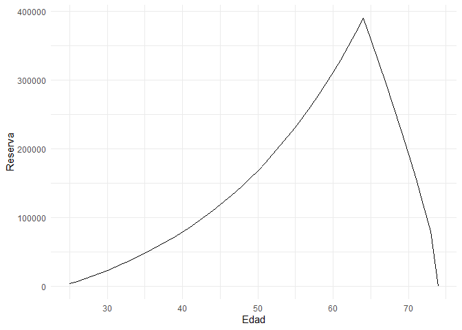

```r
# Edad
Edad <- 25:74
Reserva <- flujos$Reserva.teorica
Reserva <- data.frame("Edad" = Edad, "Reserva" = Reserva)
Reserva %>% ggplot(aes(x = Edad, y = Reserva)) +
    geom_line() +
    theme_minimal()
```

**Interpretación**

Se puede observar que conforme avanza el tiempo se aumentan las reservas por lo menos en el periodo de diferimiento, debido a que se logran obtener primas y acumular intereses sobre estas y los montos anteriormente recibidos. Al tenerse una mayor cantidad en reservas que decrementos durante el periodo de diferimiento es posible hacer la acumulación de primas sobre estos. Posteriormente llegado el periodo 40 las reservas comienzan a decrecer, esto se debe a que ya no se reciben las primas y además hay que hacer frente al pago de la anualidad vitalicia los montos de reclamo no superan inicialmente los montos en reserva por lo que se pueden seguir acumulando intereses sobre esta, pero finalmente tanto los reclamos como las reservas son iguales por lo que la reserva se hace 0, ya no se siguen acumulando intereses y todos los individuos del grupo bajo el modelo han muerto.